# Fair Advice After the Doorstroomtoets? School Disadvantage and Secondary-School Advice

DV Assignment – Final report

Group 4: Sander van Nieuwenhuijzen, Sophie Preysing, Natasha Medved

11-10-2026

## Research question and audience

The doorstroomtoets (mandatory Dutch primary school transition test for Group 8 pupils) has sparked debates about equal opportunities in education. This led the government to introduce a new doorstroomtoets in 2023 (European Education and Culture Executive Agency, 2026), aiming to improve higher education access for pupils from less privileged backgrounds. This report therefore asks: Do schools with similar test results give similar secondary-school advice, regardless of how disadvantaged their student population is? The approach is inferential: the goal is not to predict the advice of individual schools, but to test whether a school’s disadvantage is related to its advice. Two hypotheses are tested:

H1: At the same test results, schools with more disadvantaged pupils (a higher schoolweging) advise a smaller share of pupils to HAVO or higher.

H2: This gap is larger at higher test results.

The target audience is education policymakers, such as staff at the Ministry of Education (OCW). They know the debate about fair school advice but are not statistical experts, so the visualization avoids statistical jargon.

## Exploratory process

**Figure 1**

*Test results, school disadvantage and test provider (A–C)*

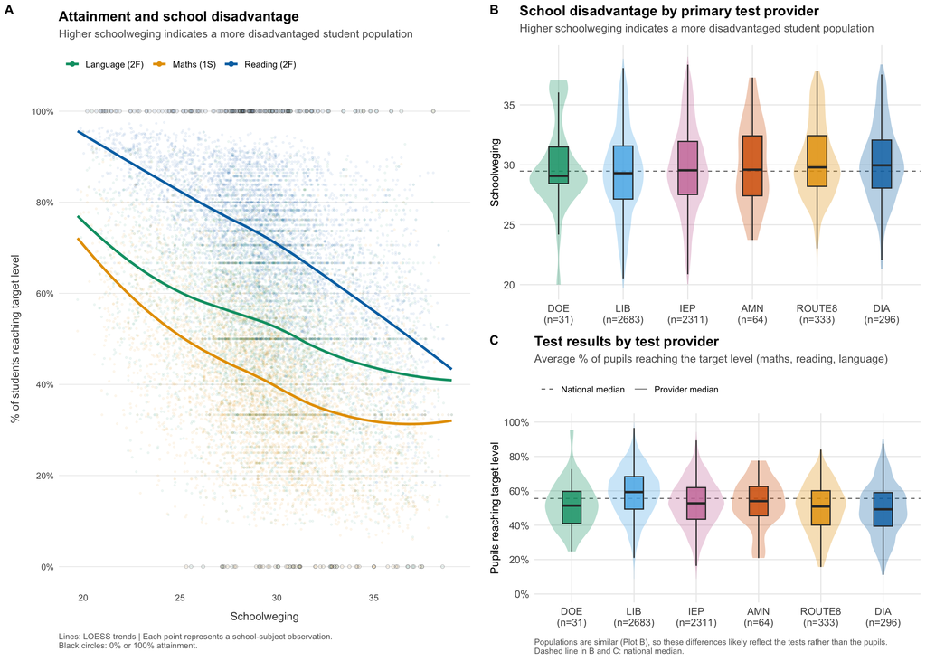

Plot A shows that all three subjects decline similarly with schoolweging and correlate moderately (r = 0.57—0.68), so they were combined into one average score. Plot B shows that schools using different test providers have similar levels of disadvantage. Plot C shows that the share of pupils reaching the target level differs between tests (LIB schools average 58.6%; schools using other tests score 5.8–9.4 percentage points lower, all p < 0.01), so the analysis controls for test provider.

## Data and preparation

The four DUO files for 2024–2025 were aggregated to one row per school and joined. Only regular primary schools were kept. The outcome, HAVO or higher, is the percentage of pupils with a HAVO, HAVO/VWO or VWO advice, out of all pupils with an advice on the PRO–VWO scale (VSO and “no advice possible” excluded). A percentage was preferred over an average advice score because it is easier for policymakers to interpret.

Test results are the average percentage of pupils reaching the target level (1S for maths, 2F for reading and language). Each school’s test provider is the test taken by most of its pupils. Schools missing from any file or with fewer than 10 advised pupils (where one pupil shifts the percentage by over 10 points) were removed. The final sample contains 5,718 schools.

The data were analysed with a linear regression of HAVO or higher on test results, schoolweging and their interaction, controlling for test provider. Schools were weighted by their number of advised pupils, as percentages of small schools are less reliable. Test results and schoolweging were centred on their mean, so the schoolweging effect describes a school with average test results.

DUO hides counts below 5 as ‘<5’; these were replaced with 2.5, the midpoint of 1–4, and tested in the robustness checks.

## Model

**Regression results** (reference provider: LIB, R² = 0.66)

| Term | Estimate | 95% CI lower | 95% CI upper | p-value |
| --- | --- | --- | --- | --- |
| Intercept | 43.799 | 43.411 | 44.187 | 0.0000 |
| Test results | 0.582 | 0.559 | 0.604 | 0.0000 |
| Schoolweging | -1.758 | -1.840 | -1.676 | 0.0000 |
| providerAMN | -3.859 | -6.237 | -1.481 | 0.0015 |
| providerDIA | 2.014 | 0.827 | 3.202 | 0.0009 |
| providerDOE | 1.311 | -1.764 | 4.387 | 0.4033 |
| providerIEP | 2.207 | 1.669 | 2.745 | 0.0000 |
| providerROUTE8 | 0.259 | -0.872 | 1.390 | 0.6534 |
| Test results x schoolweging | -0.033 | -0.037 | -0.028 | 0.0000 |

Controlling for test provider, schools with higher test results advise more pupils to HAVO or higher. At the same test results, each point higher schoolweging goes with 1.76 percentage points fewer pupils advised to HAVO or higher (95% CI: −1.84 to −1.68, p < 0.001), supporting H1.

The interaction is also negative and significant (−0.033, 95% CI: −0.037 to −0.028, p < 0.001): the positive relationship between test results and advice becomes weaker as schoolweging increases. Thus, the gap grows with test results, supporting H2.

## Final Explanatory visualization

**Figure 2**

*Predicted HAVO-or-higher advice by test results for advantaged, average and disadvantaged schools*

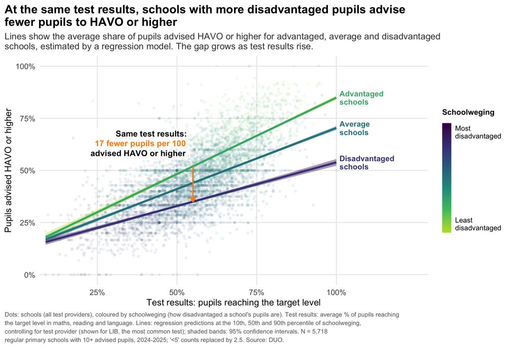

Each dot is one school, coloured from yellow-green (advantaged) to dark purple (disadvantaged). The three lines show the model’s predicted advice for schools at the 10th, 50th, and 90th percentile of schoolweging, with shaded 95% confidence intervals. The orange arrow marks the main finding: at an average test result, a disadvantaged school advises 17 fewer pupils per 100 to HAVO or higher than an advantaged school. The lines fan out to the right: the gap is small at low test results and largest at high test results.

## Robustness check

Robustness checks: schoolweging effect and interaction per model

| Model | Schoolweging estimate | Schoolweging p-value | Interaction estimate | Interaction p-value |
| --- | --- | --- | --- | --- |
| Main model (‘<5’ = 2.5) | -1.758 | 0 | -0.033 | 0 |
| Maths only | -2.100 | 0 | -0.018 | 0 |
| Average advice (1-6) | -0.053 | 0 | 0.000 | 0 |
| Without AMN and DOE | -1.764 | 0 | -0.033 | 0 |
| ‘<5’ = 1 | -2.161 | 0 | -0.014 | 0 |
| ‘<5’ = 4 | -1.426 | 0 | -0.037 | 0 |

The findings are robust. Both the schoolweging effect and the interaction remain negative and significant when using maths results only, when measuring advice as an average on a 1—6 scale, and when excluding the two smallest providers. Replacing “<5” with the most extreme values (1 or 4) changes only the strength of the effects, not their direction or significance.

## Conclusion

Schools with similar test results do not give similar advice. At the same test result, schools with more disadvantaged pupils advise fewer pupils to HAVO or higher and the gap grows as test results rise. For policymakers, this indicates that, first, pupils in disadvantaged schools may be under-advised compared with similar pupils elsewhere. Second, the gap is largest for high-scoring schools which means the pupils most likely to miss out on access to higher education are the ones who perform well at disadvantaged schools.

## Limitations and future work

The data are school-level aggregates, so the analysis cannot show whether individual pupils with the same result receive different advice. Also, the model is not causal so the gap could reflect teachers’ prejudices, or information about pupils that the test does not capture. Moreover, since 2024 schools give their advice before the test and can only adjust it upwards, so advice partly precedes the results. Future work could use pupil-level data and examine which components of schoolweging (e.g. parental education) drive the gap.

## AI use

The group used Claude Opus 5.5/Sonnet 4.6 for R code (data-inspection, cleaning and plotting suggestions), setting up the report structure and reducing the word count. The research question, hypotheses, model choice and interpretation of the results were made by the group. The AI worked from the assignment brief, the codebook, and the group’s own AI guidelines which ensured accuracy and sovereignty. The outputs were checked by peer review, which mattered because during data cleaning, the AI left out the 2F language column, which a peer caught and corrected before the analysis. The key takeaway was that AI is a useful tool but a critical lens is required.

## References

European Education and Culture Executive Agency. (2026). *Current debates and reforms: Netherlands*. Youth Wiki. https://national-policies.eacea.ec.europa.eu/youthwiki/chapters/netherlands/311-current-debates-and-reforms